# Third pilot report: the new design, with every richer model built on E1

A review document: the third pilot, its results, the spec, and the decisions log

Published

November 6, 2026

# Summary

**Scope.** This document reports the third pilot[^1], for revision 4 of the proposal (`proposal.md`, section 12): the user’s new idea, in which every richer model is built on E1, the model with the IFN score, its square, composition, and the gene levels. It covers the idea, how the pilot was run, what it found, the project spec, and the decisions made along the way. It was built from `project-spec.md`, `decisions.md`, the saved results in `pilot-c/results/`, and, read-only, the second pilot’s results in `pilot-b/results/`; every number in the text and figures is computed from those files when the document renders.

**Status.** In `STATUS.md` the third pilot is marked `piloted-pass`[^2]. Every clause of the pre-registered rule passed, and none landed within three MCSE of its threshold. With every richer model built on E1, edges still equal their first-order formula, still find a real change in co-expression (also at 40 per class, and in the conditioned network N2), and add nothing when only interferon differs.

| Pilot question | Answer | Key evidence |
| --- | --- | --- |
| 1. Does the equivalence hold on the E1 base? | pass and pass | N1 gained 0.109 (MCSE 0.0050) over E1 in cell 6 (network 0.4, share 0.5, 80 in the smaller class); N1 and F1 differed by -0.0038 to 0.0010 across all 9 cells. |
| 2. Does the signal hold at 40 per class and in N2? | pass and pass | N1 gained 0.044 (MCSE 0.0045) over E1 at 40 per class; N2 gained 0.101 (MCSE 0.0047) over E1 in cell 6. |
| 3. Does the E1 base remove the artifact? | pass and pass | In the IFN-only cells, N1 against E1 ranged over -0.0006 to 0.0014 and N2 against E1 over 0.0003 to 0.0013. |

**What needs your decision** (details in Action items and limitations): the status call; the open `[TO CONFIRM]` items in the spec (highlighted in yellow): the PRECISESADS access request, the replication downloads, and the milestone dates.

# The idea

## In plain language

LIONESS[^3] gives every patient a value for every pair of genes, called an edge, meant to say how tightly the two genes move together in that patient. The exact formula behind it says what the value is made of: the correlation of the two genes across all patients, plus the product of the patient’s own two standardized values, minus a correction for how far each gene alone sits from its average. So an edge can be computed from the patient’s expression in one line.

The new idea asks LIONESS to beat a stronger opponent than before. In the earlier pilots, LIONESS edges were added to a model with the interferon score and its square ($R_1$). Now they are added to a model that also holds every gene’s level (E1), and each competitor (the one-line formula F1, the separate products and squares E5, and the partial-correlation edges N2) is added to the same E1. This pilot asks whether the earlier findings still hold after that change: whether edges still equal their formula, whether they still find a real change in co-expression, and whether interferon still leaks through when the gene levels are in the base. No patient data were analyzed.

## Potential impact

LIONESS builds one network per sample from an aggregate network and has an R implementation (M. L. Kuijjer et al. 2019; Marieke L. Kuijjer et al. 2019). Earlier work reduced per-sample changes in correlation to a product of standardized deviations for large reference sets (Yu et al. 2017), and documented that subpopulation size and differential expression shift LIONESS edges (Kuijjer et al. 2026). New here: the exact closed form of the LIONESS edge, and the test of whether edges add anything to a classifier that already holds the gene levels, beyond their own first-order formula.

Users compare edges between groups and feed them to classifiers, and read the result as rewired gene coupling. This pilot shows that the two checks the theory proposes still hold on the stronger base. Across all 9 cells, N1 and F1 differed by -0.0038 to 0.0010 in AUC (Figure 3), so a network result is a result about a quadratic function of expression that any reader can recompute without building a network. With the IFN score, its square, and the gene levels in the base, edges added -0.0006 to 0.0014 in the IFN-only cells, while the same edges on $R_0$ gained up to 0.029 (Table 2): the interferon artifact is real, and the base removes it. And edges still found a true co-expression change that the gene levels cannot see, gaining 0.109 (MCSE 0.0050) over E1, where the same information as separate products and squares gained only 0.024 (MCSE 0.0033). The application to PRECISESADS, once access is granted, will show whether these hold in real blood.

## Application: the study behind the data

### The study

The proposed data come from PRECISESADS, a European study of systemic autoimmune diseases (Barturen et al. 2021), https://doi.org/10.1002/art.41610. It recruited a cross-sectional cohort of 955 patients with seven systemic autoimmune diseases, among them systemic lupus erythematosus (SLE) and rheumatoid arthritis (RA), and 267 healthy controls, from 18 centres, and measured the whole-blood transcriptome[^4], blood cell proportions by flow cytometry[^5], and the treatment each patient was taking; a separate inception cohort was followed over time. The data are held by ELIXIR Luxembourg under controlled access (dataset ELU-2-E592B0-1, https://doi.org/10.17881/th9v-xt85) (ELIXIR Luxembourg 2017). Access has not yet been requested, so no PRECISESADS data were opened. Two public series, GSE17755 and GSE235508, will be used to replicate the simulation’s findings inside each dataset; they have not been downloaded.

### Why the AUC difference between N1 and E1

The quantity that decides the new claim is the difference in out-of-sample area under the ROC curve[^6] (AUC) between E1 plus LIONESS edges (N1) and E1 alone. A difference near zero means the edges add nothing to the gene levels, the IFN score, and its square. Beside it, the difference between N1 and E1 plus the first-order edges (F1) asks whether whatever edges add is their formula. The proposed analysis tests the first as a superiority and the second as an equivalence (margin 0.01), in repeated nested cross-validation[^7] on PRECISESADS.

### Did the original study compute it?

No. The PRECISESADS analysis clustered patients on transcriptome and methylome features; it built no single-sample networks and fitted no classifier of SLE against RA.

## In symbols

The sample’s standardized expression of gene $i$ ($z_{qi}$, its deviation from the reference mean in units of the reference standard deviation, divisor $N$) and the reference correlation of genes $i$ and $j$ ($r$) determine the LIONESS edge of sample $q$ ($e_q$), with $a = 1/(N-1)$, and its first-order form ($f_q$):

$$\begin{aligned}
e_q &= N r - (N-1) \frac{r - a\, z_{qi} z_{qj}}{\sqrt{\left(1 - a\, z_{qi}^2\right)\left(1 - a\, z_{qj}^2\right)}}, \\
f_q &= r + z_{qi} z_{qj} - \frac{r}{2}\left(z_{qi}^2 + z_{qj}^2\right), \\
e_q &= f_q + O_p\left(N^{-1}\right).
\end{aligned}$$

| Symbol | Meaning |
| --- | --- |
| $N$ | number of samples in the reference set |
| $z_{qi}$ | expression of gene $i$ in sample $q$, standardized by the reference (divisor $N$) |
| $r$ | Pearson correlation of genes $i$ and $j$ in the reference |
| $e_q$ | exact LIONESS edge of sample $q$ for the pair $(i, j)$ |
| $f_q$ | first-order edge: the reference correlation plus the influence function of the correlation at the sample |

The partial-correlation edge of N2 replaces $r$ by the partial correlation of the two genes given the IFN score and composition, computed from residuals, with the same leave-one-out construction.

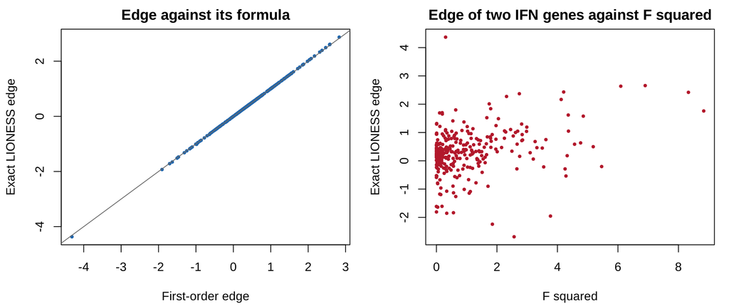

Figure 1: The idea, an illustration on made-up numbers (not pilot output): 300 simulated samples. Left: two genes correlated 0.5; each point is one sample’s exact LIONESS edge against its first-order edge, and the line is equality. Right: two genes that both load 0.8 on a factor F (interferon); each sample’s edge against F squared, which is why the base must hold the squared IFN score.

## Critiquing the model

Any model is a simplification, and the useful question is not whether it is true but where it bends and whether the bend matters for the question being asked. The model above was chosen so that the problem could be written as a formula and checked by simulation, and each simplification that made that possible is a place where real data may behave differently. The table lists the main ones. Work through it one row at a time. The first column names the feature and the symbols in the equations that carry it, so find them there first. Then decide in your own words how the feature could fail for real data before reading the second column, and finally read the third column for what should be done to check it. Several of these checks are natural first tasks for the project. Which of them the pilot examined, and which it left open, is for you to find when you read the Methods and Results that follow.

| Feature of the model | Why it may not be realistic | What should be done to check it |
| --- | --- | --- |
| Noise $\varepsilon$ normal or $t_5$ | Log expression has outliers of other shapes, and the remainder $e_q - f_q$ grows with $z^4$ | Resample real-data residuals in place of $\varepsilon$, and add single-sample outliers |
| One factor $F$ with equal loadings $a_g$ = 0.8 on 20 genes | Real IFN-stimulated genes respond with different strengths and to several IFN types | Estimate the loadings and the number of IFN factors from PRECISESADS |
| The IFN score as the mean of five genes | The score measures $F$ with error, so neither E1 nor N2’s conditioning can remove all of $F^2$ | Vary the score’s reliability in the full study (2, 5, 10 genes) |
| Composition $C$ as one factor, observed without error | Whole blood has several cell types | Use the flow-cytometry proportions of PRECISESADS |
| The gene levels in E1 carry no class signal in the IFN and network cells | In blood, genes differ in level between SLE and RA, so E1 will be a stronger base than here | Place PRECISESADS on each gradient and report E1 over $R_1$ |
| A fixed gene set of 45 genes, 990 edges | Studies select genes by variance or pathway and use thousands of edges | Selection inside each training fold in the application |

# Methods

## Design

The pilot simulates two classes of 50 genes in 9 cells, from the earlier pilots’ mechanism: genes 1 to 20 load on an IFN factor $F$, the IFN score is the mean of genes 1 to 5, genes 21 to 30 form a co-expressed module, and genes 31 to 50 load on a composition factor $C$. Each cell lets the classes differ in one way: not at all, in the distribution of $F$, in the means of the module genes, or in the module’s correlation. Two cells replace normal noise by heavy-tailed noise. In each replicate, nine models are fitted in an outer 5-fold cross-validation, with every derived quantity computed inside the training fold.

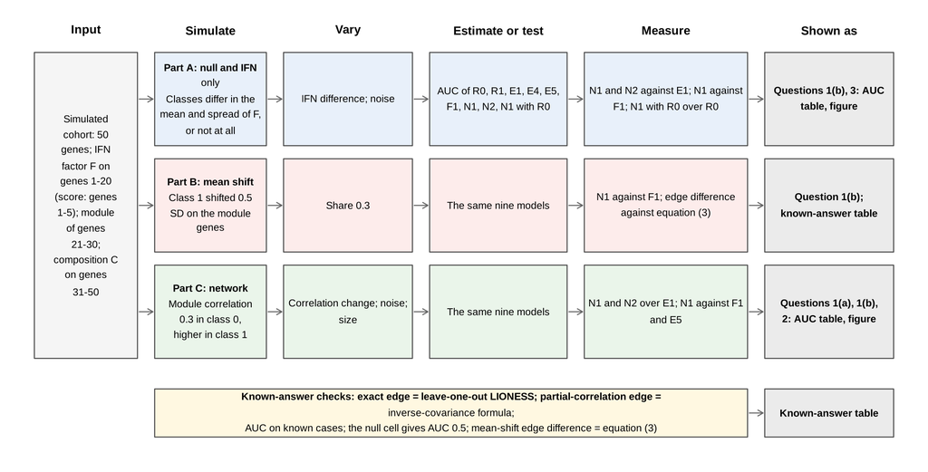

Figure 2: The design at a glance. Each row is one part of the pilot, read from left to right: what is simulated, which factors are varied, what is estimated, what is measured, and how the result is shown. Every part feeds the AUC table (Table 2) and the figure of differences (Figure 3); the verdict is in Table 3, and the known-answer checks in Table 1.

Each figure and table in the Results traces back to one row of this diagram.

| Part | What is simulated | Main factors | Replicates |
| --- | --- | --- | --- |
| A | Null (cell 1) and IFN only (cells 2 to 4) | IFN difference (moderate, large); $t_5$ noise | 200 per cell |
| B | Mean shift of 0.5 SD on the module (cell 5) | share 0.3, 80 in the smaller class | 200 per cell |
| C | Module correlation change (cells 6 to 9) | change 0.2 or 0.4; $t_5$ noise; 40 or 80 in the smaller class | 200 per cell |

The nine models are: $R_0$, logistic regression on age, sex, composition, and the residual IFN score; $R_1$, $R_0$ plus the squared residual score and squared composition; E1, an elastic net[^8] on the 45 non-score genes with the $R_1$ terms unpenalized; E4, regularized discriminant analysis on the 45 genes with composition and the residual score; and four models that add one penalized feature set to E1: E5 (the 990 pairwise products and 45 squares of the standardized genes), F1 (the 990 first-order edges), N1 (the 990 exact LIONESS edges), and N2 (the 990 LIONESS edges of the partial correlation given the IFN score and composition). The ninth, N1 with $R_0$, puts the LIONESS edges on $R_0$ alone, to show the artifact. The large IFN difference shifts the mean of $F$ by 1 standard deviation and multiplies its spread by 2.25 in class 1, the moderate one by 0.5 and 1.5.

## Known-answer checks

Known-answer checks come before any result, because every later number is only as good as the simulation that produced it. Each check sets up a case where the correct answer is known from theory, runs the simulation code on it, and compares the two. Agreement says nothing about the scientific question or about real data. It says that the code does what the model says. Disagreement means stopping to look for a bug before reading anything else, and the same checks apply to any code you write for the project.

Read each row of the table in four steps: the setting that was simulated, the known answer for that setting, what the simulation gave, and whether the gap between the two is small compared with the Monte Carlo standard error (MCSE). The MCSE is how much a simulated result moves from run to run because only a finite number of replicates was used. A gap within about two MCSE is noise, and a gap of several MCSE is a problem.

Table 1: Known-answer checks, from `results/known_answers.rds`.

| Check | Setting | Known answer | Simulation gave | How to read it |
| --- | --- | --- | --- | --- |
| Exact LIONESS Pearson edge equals leave-one-out LIONESS | N = 12, 6 genes, one outlier; largest absolute difference | 0.000 | 8.88e-15 | 8.882e-15 from the known value, against a tolerance of 1e-08, so the check passes. |
| Exact add-one edge equals (N + 1) r(+q) - N r | reference N = 12, 5 new samples; largest absolute difference | 0.000 | 5.33e-15 | 5.329e-15 from the known value, against a tolerance of 1e-08, so the check passes. |
| Exact LIONESS Pearson edge equals leave-one-out LIONESS | N = 60, 6 genes, one outlier; largest absolute difference | 0.000 | 1.42e-14 | 1.421e-14 from the known value, against a tolerance of 1e-08, so the check passes. |
| Exact add-one edge equals (N + 1) r(+q) - N r | reference N = 60, 5 new samples; largest absolute difference | 0.000 | 1.07e-14 | 1.066e-14 from the known value, against a tolerance of 1e-08, so the check passes. |
| First-order edge approaches the exact edge as N grows | N = 4000, r = 0.5; largest absolute difference | 0.000 | 0.0123 | 0.01235 from the known value, against a tolerance of 0.05, so the check passes. |
| AUC of perfectly separated scores | 5 against 5 | 1.000 | 1 | 0 from the known value, against a tolerance of 1e-08, so the check passes. |
| AUC of tied scores | all scores equal | 0.500 | 0.5 | 0 from the known value, against a tolerance of 1e-08, so the check passes. |
| Partial-correlation LIONESS edge equals the inverse-covariance formula | N = 30, 4 genes, 2 conditioning variables; largest absolute difference | 0.000 | 1.07e-14 | 1.066e-14 from the known value, against a tolerance of 1e-08, so the check passes. |
| Partial-correlation add-one edge equals the inverse-covariance formula | reference N = 30, 3 new samples; largest absolute difference | 0.000 | 7.11e-15 | 7.105e-15 from the known value, against a tolerance of 1e-08, so the check passes. |
| Partial-correlation edge with no conditioning set equals the Pearson edge | N = 30, 4 genes; largest absolute difference | 0.000 | 5.33e-15 | 5.329e-15 from the known value, against a tolerance of 1e-08, so the check passes. |
| Null cell: AUC of R0 is 0.5 | cell 1 (share 0.5, n 80), 200 replicates | 0.500 | 0.4806 (MCSE 0.0046) | 4.3 MCSE from the known value, so the gap is too large: look for a bug. |
| Null cell: AUC of R1 is 0.5 | cell 1 (share 0.5, n 80), 200 replicates | 0.500 | 0.4851 (MCSE 0.0047) | 3.1 MCSE from the known value, so the gap is too large: look for a bug. |
| Null cell: AUC of E1 is 0.5 | cell 1 (share 0.5, n 80), 200 replicates | 0.500 | 0.4852 (MCSE 0.0046) | 3.3 MCSE from the known value, so the gap is too large: look for a bug. |
| Null cell: AUC of E4 is 0.5 | cell 1 (share 0.5, n 80), 200 replicates | 0.500 | 0.5024 (MCSE 0.0039) | 0.6 MCSE from the known value, so the gap is noise. |
| Null cell: AUC of N1R0 is 0.5 | cell 1 (share 0.5, n 80), 200 replicates | 0.500 | 0.4839 (MCSE 0.0043) | 3.7 MCSE from the known value, so the gap is too large: look for a bug. |
| Null cell: AUC of E5E1 is 0.5 | cell 1 (share 0.5, n 80), 200 replicates | 0.500 | 0.4864 (MCSE 0.0046) | 3.0 MCSE from the known value, so the gap is too large: look for a bug. |
| Null cell: AUC of F1E1 is 0.5 | cell 1 (share 0.5, n 80), 200 replicates | 0.500 | 0.4863 (MCSE 0.0046) | 3.0 MCSE from the known value, so the gap is too large: look for a bug. |
| Null cell: AUC of N1E1 is 0.5 | cell 1 (share 0.5, n 80), 200 replicates | 0.500 | 0.4873 (MCSE 0.0045) | 2.8 MCSE from the known value, so the gap is too large: look for a bug. |
| Null cell: AUC of N2E1 is 0.5 | cell 1 (share 0.5, n 80), 200 replicates | 0.500 | 0.4869 (MCSE 0.0046) | 2.8 MCSE from the known value, so the gap is too large: look for a bug. |
| Mean shift: class difference in mean edge minus equation (3) | cell 5 (share 0.3, n 80), module pairs, 200 replicates | 0.000 | -0.0021 (MCSE 0.0036) | 0.6 MCSE from the known value, so the gap is noise. |

# Results

## How to read the outputs

Each output traces back to a row of the design diagram (the captions name the part where one applies). Read each in the same four steps. First, find its row in the diagram, which says what was simulated and what was varied. Second, work out what one point or one table entry is, usually one combination of the varied factors, averaged over replicates. Third, identify the reference value that would hold if nothing were wrong, shown as a dashed or grey line wherever possible. Fourth, look for where the results leave that reference, and for which settings they do. The outputs report three kinds of quantity.

- **Bias** is the average of an estimate minus its true value. When the truth is no difference, any average difference from 0 is a spurious difference created by the problem under study.
- **Level** is how often a test rejects when there is truly nothing to find. A correct test at 0.05 rejects 5% of the time, so a rate above 0.05 means too many false alarms.
- **Power** is how often a test rejects when there is a real effect. More is better, but only when the level is not inflated, because a test that rejects too often also looks powerful.

All rates and averages come from simulation, so each carries Monte Carlo error. That is why the figures show bars or a grey band, and why small differences should not be over-read.

This pilot reports AUC and paired AUC differences. A paired difference is computed within each replicate, between two models fitted to the same simulated cohort, and then averaged; its MCSE is the replicate standard deviation of the difference divided by the square root of the number of replicates. A difference of 0 means the two models did equally well.

## AUC differences by cell

**Figure guide (all parts).** Each row is one cell, labelled by its mechanism, level, stress factor if any, share of the smaller class ($\pi$), and size of the smaller class ($n$). The five colored points are paired AUC differences averaged over 200 replicates: N1 with $R_0$ against $R_0$ (the artifact); N1 against E1; N2 against E1; E5 against E1; and N1 against F1. The bars are two MCSE on each side, and the grey line is no difference. Look for: whether the purple points sit on the line in every row; whether the blue and orange points sit on the line in the IFN-only rows and away from it in the network rows; where the green points fall short of the blue.

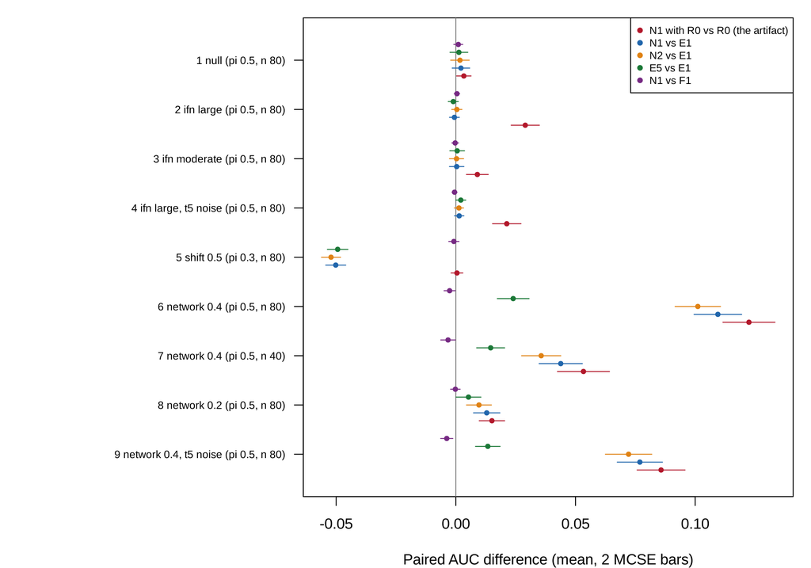

Figure 3: Third pilot result (all parts): paired AUC differences by cell, means over replicates with bars of two MCSE, from `results/cell_summaries.rds`.

## Numbered findings

Each finding is a claim followed by the output behind it. Read the claim, open the output, and check that you can see the claim there before accepting it.

1. **N1 and F1 perform the same on the E1 base.** Their AUC difference ranged over -0.0038 to 0.0010 across all 9 cells (Table 3, purple points in Figure 3), within the pre-registered margin of 0.01 in every cell. The largest, -0.0038 (MCSE 0.0013), was in cell 9 (network 0.4, t5 noise, share 0.5, 80 in the smaller class), and favored the first-order edges, as with heavy-tailed noise in the second pilot.
2. **There was a real signal to match.** In cell 6 (network 0.4, share 0.5, 80 in the smaller class), N1 gained 0.109 (MCSE 0.0050) over E1, and 0.044 (MCSE 0.0045) with 40 in the smaller class (Table 3, blue points).
3. **The conditioned network keeps the signal.** N2 gained 0.101 (MCSE 0.0047) over E1 in cell 6, 0.0084 less than N1 (orange points).
4. **The E1 base removes the interferon artifact.** In the IFN-only cells, N1 against E1 ranged over -0.0006 to 0.0014 and N2 against E1 over 0.0003 to 0.0013, while N1 with $R_0$ gained 0.029 (MCSE 0.0030) over $R_0$ at a large IFN difference, 0.021 (MCSE 0.0030) with $t_5$ noise, and 0.0090 (MCSE 0.0023) at a moderate one (red points). The second pilot’s estimate in its large cell was 0.0201 (MCSE 0.0027).
5. **The edge form beats separate products and squares.** In the network cells, N1 gained over E5 by 0.008 to 0.086, although both hold the same quadratic information (green against blue points). E4, quadratic discriminant analysis, gained 0.069 (MCSE 0.0061) over E1 in cell 6, less than N1.
6. **Features without signal cost AUC.** In cell 5 (mean shift 0.5, share 0.3, 80 in the smaller class), where the signal is in the gene levels, E1 gained 0.152 (MCSE 0.0043) over $R_1$, and adding the 990 edges lowered the AUC by 0.050 (Table 2): the penalty is diluted. So $\Delta_1$ can be negative in real data without any harm from edges as such (decisions log, D8).
7. **The known-answer checks hold, with one flag.** Every code identity, including the partial-correlation edges against the inverse-covariance formula, agreed to better than $10^{-13}$, and the mean-shift formula held; in the null cell every model but E4 sat below 0.5 by 2.8 to 4.3 MCSE, shared by the models the clauses compare, so the paired differences are unaffected (Table 1; decisions log, D7).

## Tables

**Table guide (all parts).** One row per cell; the columns are the mean out-of-fold AUC of each model over 200 replicates. The reference value is 0.5 in the null cell. Compare N1 against E1 and F1 in the same row, and N2 against N1.

Table 2: Mean out-of-fold AUC by cell and model, from `results/cell_summaries.rds`. The largest MCSE of any entry is given in the text below the table.

| Cell | R0 | R1 | E1 (genes) | E4 (RDA) | E5 (E1 + products, squares) | F1 (E1 + first-order edges) | N1 (E1 + edges) | N2 (E1 + partial edges) | N1 with R0 |
| --- | --- | --- | --- | --- | --- | --- | --- | --- | --- |
| cell 1 (null, share 0.5, 80 per class) | 0.481 | 0.485 | 0.485 | 0.502 | 0.486 | 0.486 | 0.487 | 0.487 | 0.484 |
| cell 2 (IFN only large, share 0.5, 80 in the smaller class) | 0.626 | 0.711 | 0.710 | 0.707 | 0.709 | 0.709 | 0.709 | 0.710 | 0.655 |
| cell 3 (IFN only moderate, share 0.5, 80 in the smaller class) | 0.557 | 0.589 | 0.588 | 0.587 | 0.589 | 0.589 | 0.589 | 0.589 | 0.566 |
| cell 4 (IFN only large, t5 noise, share 0.5, 80 in the smaller class) | 0.625 | 0.709 | 0.706 | 0.695 | 0.709 | 0.708 | 0.708 | 0.708 | 0.646 |
| cell 5 (mean shift 0.5, share 0.3, 80 in the smaller class) | 0.494 | 0.496 | 0.648 | 0.678 | 0.599 | 0.599 | 0.598 | 0.596 | 0.495 |
| cell 6 (network 0.4, share 0.5, 80 in the smaller class) | 0.490 | 0.493 | 0.494 | 0.563 | 0.518 | 0.606 | 0.604 | 0.595 | 0.613 |
| cell 7 (network 0.4, share 0.5, 40 in the smaller class) | 0.494 | 0.494 | 0.493 | 0.525 | 0.508 | 0.540 | 0.537 | 0.529 | 0.547 |
| cell 8 (network 0.2, share 0.5, 80 in the smaller class) | 0.499 | 0.500 | 0.502 | 0.509 | 0.508 | 0.515 | 0.515 | 0.512 | 0.514 |
| cell 9 (network 0.4, t5 noise, share 0.5, 80 in the smaller class) | 0.482 | 0.483 | 0.484 | 0.553 | 0.497 | 0.565 | 0.561 | 0.556 | 0.568 |

The largest MCSE of an AUC in the table is 0.0062.

**Table guide (the verdict).** One row per clause of the pre-registered rule: the quantity, its value with its MCSE, the threshold, and the outcome, read by `pilot-c/verdict.R`. Check that each outcome follows from its value and threshold, and that the combination gives the status.

Table 3: The pass rule applied clause by clause, from `results/verdict.rds`.

| Q | Clause | Cell | Quantity | Value | MCSE | Threshold | Outcome |
| --- | --- | --- | --- | --- | --- | --- | --- |
| 1 | (a) | cell 6 (network 0.4, share 0.5, 80 in the smaller class) | A(N1) - A(E1) | 0.1095 | 0.0050 | >= 0.05 and > 3 MCSE | pass |
| 1 | (b) | cell 1 (null, share 0.5, 80 per class) | A(N1) - A(F1) | 0.0010 | 0.0009 | \|D\| <= 0.0100 | pass |
| 1 | (b) | cell 2 (IFN only large, share 0.5, 80 in the smaller class) | A(N1) - A(F1) | 0.0005 | 0.0006 | \|D\| <= 0.0100 | pass |
| 1 | (b) | cell 3 (IFN only moderate, share 0.5, 80 in the smaller class) | A(N1) - A(F1) | -0.0003 | 0.0007 | \|D\| <= 0.0100 | pass |
| 1 | (b) | cell 4 (IFN only large, t5 noise, share 0.5, 80 in the smaller class) | A(N1) - A(F1) | -0.0005 | 0.0005 | \|D\| <= 0.0100 | pass |
| 1 | (b) | cell 5 (mean shift 0.5, share 0.3, 80 in the smaller class) | A(N1) - A(F1) | -0.0008 | 0.0011 | \|D\| <= 0.0100 | pass |
| 1 | (b) | cell 6 (network 0.4, share 0.5, 80 in the smaller class) | A(N1) - A(F1) | -0.0026 | 0.0012 | \|D\| <= 0.0100 | pass |
| 1 | (b) | cell 7 (network 0.4, share 0.5, 40 in the smaller class) | A(N1) - A(F1) | -0.0033 | 0.0015 | \|D\| <= 0.0100 | pass |
| 1 | (b) | cell 8 (network 0.2, share 0.5, 80 in the smaller class) | A(N1) - A(F1) | -0.0002 | 0.0010 | \|D\| <= 0.0100 | pass |
| 1 | (b) | cell 9 (network 0.4, t5 noise, share 0.5, 80 in the smaller class) | A(N1) - A(F1) | -0.0038 | 0.0013 | \|D\| <= 0.0100 | pass |
| 2 | (a) | cell 7 (network 0.4, share 0.5, 40 in the smaller class) | A(N1) - A(E1) | 0.0438 | 0.0045 | >= 0.03 | pass |
| 2 | (b) | cell 6 (network 0.4, share 0.5, 80 in the smaller class) | A(N2) - A(E1) | 0.1011 | 0.0047 | >= 0.05 | pass |
| 3 | (a) | cell 2 (IFN only large, share 0.5, 80 in the smaller class) | A(N1) - A(E1) | -0.0006 | 0.0010 | \|E\| <= 0.0100 | pass |
| 3 | (a) | cell 3 (IFN only moderate, share 0.5, 80 in the smaller class) | A(N1) - A(E1) | 0.0004 | 0.0015 | \|E\| <= 0.0100 | pass |
| 3 | (a) | cell 4 (IFN only large, t5 noise, share 0.5, 80 in the smaller class) | A(N1) - A(E1) | 0.0014 | 0.0010 | \|E\| <= 0.0100 | pass |
| 3 | (b) | cell 2 (IFN only large, share 0.5, 80 in the smaller class) | A(N2) - A(E1) | 0.0004 | 0.0011 | \|E\| <= 0.0100 | pass |
| 3 | (b) | cell 3 (IFN only moderate, share 0.5, 80 in the smaller class) | A(N2) - A(E1) | 0.0003 | 0.0015 | \|E\| <= 0.0100 | pass |
| 3 | (b) | cell 4 (IFN only large, t5 noise, share 0.5, 80 in the smaller class) | A(N2) - A(E1) | 0.0013 | 0.0010 | \|E\| <= 0.0100 | pass |

**Table guide (numbers quoted in the spec).** Each row recomputes a number that section 3 of the spec quotes, from the result files.

Table 4: Numbers quoted in the spec’s section 3 for the third pilot, recomputed from `results/cell_summaries.rds` and `results/verdict.rds`.

| Quantity | Value |
| --- | --- |
| 1(a): N1 over E1, cell 6 | 0.1095 (MCSE 0.0050) |
| 1(b): range of A(N1) - A(F1) over all cells | -0.0038 to 0.0010 |
| 2(a): N1 over E1, cell 7 | 0.0438 (MCSE 0.0045) |
| 2(b): N2 over E1, cell 6 | 0.1011 (MCSE 0.0047) |
| 3(a): range of N1 over E1, cells 2, 3, 4 | -0.0006 to 0.0014 |
| 3(b): range of N2 over E1, cells 2, 3, 4 | 0.0003 to 0.0013 |
| Artifact, not judged: N1 with R0 over R0, cell 2 | 0.0290 (MCSE 0.0030) |
| Status | piloted-pass |

# The draft spec

This is `project-spec.md`, read from the file when the document renders. Anything the agent[^9] left for the user to decide is highlighted in yellow and starts with “To confirm”.

| Proposal | `proposal.md`, revision 4, final 2026-11-06 |
| --- | --- |
| Authors | as in `DESCRIPTION`, set by `tools/authors.R` before the final render |
| Written | 2026-11-06 (replaces the spec of 2026-11-03) |
| Status | final 2026-11-06; section 3 completed after the third pilot’s verdict, 2026-11-06 |

## 1. Question and why it matters

**Question (one sentence):** Is a LIONESS co-expression edge anything more than a closed-form quadratic function of each sample’s own expression, and, when classifying SLE against RA from whole blood, do LIONESS edges add information beyond the IFN score, its square, cell composition, the gene levels, and their own first-order features?

**Why it matters:** LIONESS edges are read as each patient’s own co-expression network, and differences between groups are reported as rewiring. If an edge is a quadratic function of the patient’s own expression, a network finding must survive two comparisons before it means co-expression: against its own first-order formula, and against a baseline that holds the square of any shared factor such as interferon. In SLE and RA, where many gene pairs share the IFN factor, a network finding that skips these comparisons can be interferon in disguise.

## 2. Mechanism we suspect

The LIONESS edge is $e_q = N r - (N - 1) r_{(-q)}$, and its exact closed form (proposal, equation 2) equals, to first order, $r + z_{qi} z_{qj} - \tfrac{r}{2}(z_{qi}^2 + z_{qj}^2)$: the reference correlation plus the influence function of the correlation at the sample. Three gaps follow. Genes sharing a factor $F$ give $z_{qi} z_{qj} \approx a_i a_j F_q^2$, so edges gain over a baseline with $F$ but not $F^2$ whenever the classes differ in the distribution of $F$. A mean shift between unbalanced classes moves the group mean of an edge by $(1 - 2\pi)[\Delta_i \Delta_j - \tfrac{r}{2}(\Delta_i^2 + \Delta_j^2)]$ with no change in co-expression. And the classification gain of edges should equal that of their first-order formula. If the mechanism were wrong, edges would beat the formula, or would keep a gain over a baseline that holds $F^2$ and the gene levels when only $F$ differs.

## 3. Pilot

Filled twice: the plan now, the answers after the verdict (stage 2, step 5). This is the third pilot; the first two are summarized at the end of this section.

**Code:** `pilot-c/pilot.R`, run from the project root with `Rscript pilot-c/pilot.R --reps <n>`; functions in `R/`, tests in `tests/testthat/`; the verdict by `Rscript pilot-c/verdict.R`.

**Pass rule:** from the proposal, section 12, clause by clause in `pilot-c/preregistration.md`, section 2. $\Delta_1 = \mathrm{AUC}(\text{N1}) - \mathrm{AUC}(\text{E1})$ and $\Delta_2 = \mathrm{AUC}(\text{N1}) - \mathrm{AUC}(\text{F1})$, paired within a replicate.

1. Does the equivalence hold on the E1 base? (a) In the strong network cell (cell 6), $\Delta_1 \ge 0.05$ and above three MCSE. (b) In every cell, $\lvert \Delta_2 \rvert \le \max(0.01, 3\,\text{MCSE})$.
2. Does the signal survive at a small size and in the conditioned network? (a) At 40 per class (cell 7), $\Delta_1 \ge 0.03$. (b) In cell 6, N2 gains at least 0.05 over E1.
3. Does the E1 base remove the interferon artifact? (a) In the IFN-only cells (2, 3, 4), $\lvert \Delta_1 \rvert \le \max(0.01, 3\,\text{MCSE})$. (b) The same for N2 against E1.

Pass if every clause passes; fail if 1(a), 1(b), or 3(a) fails; close call otherwise, and for any clause within three MCSE of its threshold.

**Verdict file:** `pilot-c/results/verdict.rds` (status `piloted-pass`), from `Rscript pilot-c/verdict.R`; 200 replicates per cell, 9 cells, 55 minutes on three cores.

**Plot:** `pilot-c/results/auc_gains.png`.

**The three pilot answers:**

1. Does the equivalence hold on the E1 base? Yes: N1 gained 0.109 (MCSE 0.005) over E1 in the strong network cell, and N1 and F1 differed by -0.0038 to 0.0010 in AUC across all nine cells.
2. Does the signal survive at a small size and in the conditioned network? Yes: N1 gained 0.044 (MCSE 0.005) over E1 at 40 per class, and N2 gained 0.101 (MCSE 0.005) over E1 in the strong network cell.
3. Does the E1 base remove the interferon artifact? Yes: in the IFN-only cells N1 against E1 ranged from -0.0006 to 0.0014, and N2 against E1 from 0.0003 to 0.0013, while N1 with $R_0$ gained 0.029 (MCSE 0.003) over $R_0$ at a large IFN difference.

**The earlier pilots, for the record.** The first pilot (`pilot/`, 16 cells, 180 replicates) failed its rule: the IFN artifact was small (0.0067 at a moderate IFN difference) and the planned competitor, separate products and squares, reached only a quarter of the edges’ gain with a true co-expression change, while first-order edges matched it. The second pilot (`pilot-b/`, 12 cells, 200 replicates) was a close call read as a pass: edges and first-order edges differed by -0.0054 to 0.0017 in AUC, the co-expression gain was 0.118 (MCSE 0.005), the artifact at a large IFN difference was 0.0201 (MCSE 0.0027) against a threshold of 0.02, and the squared score removed it. Both built the richer models on $R_1$.

## 4. ADEMP skeleton

**Aims.** (1) Do LIONESS edges and their first-order features give the same out-of-sample AUC? (2) How much do edges gain from the squared IFN level alone, and does a base with the squared score remove it? (3) Does the edge form detect a co-expression difference that separate products and squares miss? (4) Does equation (3) hold for unequal groups?

**Data-generating mechanisms.**

- Factors varied: share of the smaller class (0.5, 0.3, 0.15) and mean shift (0.25, 0.5, 1) in S1; IFN difference (none to very large), score genes (2, 5, 10), noise (normal, $t_5$), and size (40 to 300) in S2-A; module correlation change (0 to 0.4), size, share, noise (normal, $t_5$, $t_3$), and elastic-net mixing (0, 0.5, 1) in S2-B; one factor at a time around base settings (9 settings in S1, 25 in S2).
- Factors fixed: 50 genes (20 on the IFN factor, 5 of them the score; a 10-gene module; 20 on composition), as in the pilots, so the results stay comparable; composition observed without error and the gene set fixed at the 45 non-score genes, named as limitations.
- Known-answer cells: the null (every AUC near 0.5); equation (3) in S1; the closed forms against literal LIONESS (tests).

**Estimands.** The out-of-sample AUC of each model, the probability that a random class-1 sample outranks a random class-0 sample under the model fitted on a sample of the cell’s size; the contrasts $\Delta_1$, $\Delta_2$, $A$, and $P$ of proposal equation (6).

**Methods compared.** $R_0$, $R_1$ (logistic regression); E1, E5, F1, N1, N2 (elastic net, mixing 0.5, penalty by inner 5-fold cross-validation, glmnet 5.2, the base terms unpenalized; E5, F1, N1, and N2 add their features to E1); E4 (regularized discriminant analysis on the genes with composition and the IFN score, tuned on a grid by inner 5-fold cross-validation); N1 with $R_0$. Outer 5-fold cross-validation stratified by class; LIONESS test edges by the add-one form.

**Performance measures.** Pooled out-of-fold AUC and the paired contrasts with Monte Carlo standard errors; in S1, the bias of the class difference in mean edge against equation (3); in seven test settings, the rejection rate of the $\Delta_1$ test and the rate at which equivalence of $\Delta_2$ (margin 0.01) is declared.

**Replicates and Monte Carlo SE target.** 400 per S2 setting (MCSE near 0.002 for a contrast with replicate standard deviation 0.04); 300 in the test settings (MCSE 0.013 for a rate near 0.05); 1,000 per S1 setting.

## 5. Application

**Dataset:** PRECISESADS, ELIXIR Luxembourg ELU-2-E592B0-1 (doi 10.17881/th9v-xt85), controlled access, not yet requested, so not on disk. **To confirm:** the access request, asking for the inception cohort and the centre labels; the fallback if refused Replication: GSE17755 (22 SLE and 93 RA, females) and GSE235508 (16 SLE and 23 RA at one time point), public, not yet downloaded; the download needs the user’s approval.

**Comparison:** untreated SLE against untreated RA in whole-blood RNA-seq, with flow-cytometry composition, centre, and batch.

**What to show:** whether edges keep any gain over E1 in real blood, whether that gain equals the first-order formula’s, and whether the gain over $R_0$ is the squared IFN level.

The pilot is a simulation only, as the proposal states (section 12).

## 6. Target journal

**Target journal:** BMC Bioinformatics

**Fallback:** Statistical Applications in Genetics and Molecular Biology

**The target’s word limit and AI policy:** structured abstract (Background, Results, Conclusions), 350 words; research article length not stated; AI use disclosed, AI not an author.

## 7. Milestones

| Stage | Ends with | Due |
| --- | --- | --- |
| 2. Pilot | `pilot-c/pilot-report.html`, the verdict file, `pilot-c/decisions.md` | 2026-11-06 |
| 3. Manuscript, design stop | `protocol.md` from the approved design | **To confirm:** date |
| 3. Manuscript, first draft | `manuscript/manuscript.html` in draft mode | **To confirm:** date |
| 3. Manuscript, settled | the draft after the revision rounds | **To confirm:** date |
| 4. Background report | `background/background.html` | **To confirm:** date |
| 5. Mock review | the last `review/round-N/` | **To confirm:** date |
| Submission | the final render and the checker in final mode | **To confirm:** date |

## 8. Out of scope

The project must not add:

- Other single-sample methods (SSN, iENA, SWEET, BONOBO, CSN, SSPGI) as fitted models: the theory paragraph covers them, and a benchmark of them is a different paper.
- Population-level network methods (module eigengenes, differential-correlation pairs) and other classifiers (random forests, shrinkage linear discriminant analysis).
- A new or corrected single-sample network method: a constructive paper for later.
- Disease pairs beyond SLE and RA as main results, although PRECISESADS holds seven diseases; Sjögren’s against RA is at most a replication of the artifact.
- A diagnostic classifier for clinical use: the classification task is the instrument, not the result.

## 9. Reading

1. 1. After reading, a reader can answer: what are the aggregate and the background network, and how is the sample’s edge obtained from them?
2. 2. After reading, a reader can answer: under what condition does the per-sample change in Pearson correlation reduce to the product of standardized deviations, and what does that reduction drop?
3. 3. After reading, a reader can answer: which edge type gets higher weights in the smaller subpopulation, and for which methods?

# Decisions log

This is the agent’s `decisions.md` for the third pilot, read from the file when the document renders.

## D0. Literature pass

As for the earlier pilots (`pilot/decisions.md`, D0): the proposal’s section 5, read in full text at the stage 1 reference check. For revision 4, PubMed and GEO were searched on 2026-11-06 (`log/01-idea-review.md`, searches 32 to 34); one entry was added to the reference list (`sentis2026lupusarthritis`), for the validation plan, not for this pilot. The pilot follows revision 4 of the proposal, section 12, the user’s new idea.

## D1. Status call

**What.** `piloted-pass`, by the pre-registered rule (`pilot-c/results/verdict.rds`): all 18 clause rows passed, none within three MCSE of its threshold. **The numbers.** 1(a): N1 gained 0.109 (MCSE 0.005) over E1 in the strong network cell. 1(b): N1 and F1 differed by -0.0038 to 0.0010 across all nine cells. 2(a): 0.044 (MCSE 0.005) at 40 per class. 2(b): N2 gained 0.101 (MCSE 0.005) over E1. 3(a): N1 against E1 in the IFN-only cells, -0.0006 to 0.0014. 3(b): N2 against E1, 0.0003 to 0.0013 (`pilot-c/results/cell_summaries.rds`). **No close-call reading is needed.** Neither open case of the pre-registration’s section 5 decided a clause: no value of 1(b), 3(a), or 3(b) came near the margin, on either side. **What the user should check.** Whether to start stage 3, whose design stop writes `protocol.md` from the design of proposal section 7.3.

## D2. What this pilot tests, and what it does not

**What.** The pass rule judges only what revision 4 changed: the richer models built on E1 (questions 1 and 3), the new partial-correlation edges N2 (clauses 2(b) and 3(b)), and the co-expression signal at a small size over the new base (clause 2(a)). The interferon artifact over $R_0$ is reported in every cell but judged in none. **Alternatives.** Repeating the second pilot’s clause on the artifact (at least 0.02 at a large IFN difference). **Why.** The models of that clause ($R_0$ and N1 with $R_0$) did not change, and the second pilot measured it (0.0201, MCSE 0.0027, `pilot-b/results/cell_summaries.rds`); judging it again would test the same thing on new seeds. **What the user should check.** That the rule asks the questions the new design raises (`pilot-c/preregistration.md`, section 2).

## D3. N2’s conditioning set and its computation

**What.** N2 conditions each gene pair on the IFN score (the mean of genes 1 to 5 standardized by the training fold) and composition, and its edges are computed directly: the partial correlation of the training fold, and of the training fold without each sample (or with each test sample added), from residuals on an intercept and the two conditioning variables. **Alternatives.** The first-order form of Result 2 with its Mahalanobis inflation factor; conditioning on the residual IFN score. **Why.** The direct computation is the definition, so N2 needs no approximation, and it is checked against a literal inverse-covariance formula (`pilot-c/results/known_answers.rds`). The raw score and composition span the same space as the residual score and composition, so the partial correlations are the same.

## D4. E4’s inputs

**What.** E4 is regularized discriminant analysis on the 45 genes, composition, and the residual IFN score, as in the first pilot, without the squared terms of $R_1$. **Why.** A quadratic discriminant forms squares and products of its inputs itself; adding the squared terms as inputs would add them twice.

## D5. Warnings from the elastic net

**What.** `RunReplicate()` is wrapped in `suppressWarnings()` in `pilot-c/pilot.R`. **Why.** `glmnet` warns when the path does not converge for its largest penalty values in small folds; it returns the solutions for the other values, and `lambda.min` is chosen among them. In the earlier pilots the same warnings were raised inside the parallel workers and not shown. Suppressing them changes no result.

## D6. Seeds

**What.** Cell $c$ has seed $20361103 + 1000c$. **Why.** At least 75,000 from every seed of the first two pilots, so that no replicate stream overlaps theirs; a test checks it (`tests/testthat/test-partial.R`).

## D7. The null cell sits below 0.5, as in the earlier pilots

**What.** In the null cell the pooled out-of-fold AUC of every model except E4 sat 2.8 to 4.3 MCSE below 0.5 (0.481 to 0.487; `pilot-c/results/known_answers.rds`); E4 sat at 0.502. **Why it does not affect the verdict.** The shortfall is shared by the models the clauses compare, so their paired differences in the null cell are 0.0009 to 0.0034; E4, which does not share it, sits 0.017 (MCSE 0.006) above E1 there, and no clause uses E4. Pooling out-of-fold scores across folds whose models differ is known to pull a no-signal AUC below 0.5; the second pilot showed the same (`pilot-b/decisions.md`, D6). **What the user should check.** Whether the full study should also report the fold-averaged AUC, which the second pilot’s report raised for stage 3.

## D8. Findings outside the rule, for the design

**What.** Three results that no clause judges, recorded because the full study and the application depend on them (`pilot-c/results/cell_summaries.rds`). 1. In the mean-shift cell, where the signal is in the gene levels, adding 990 edges (or products, or first-order edges) to E1 lowered the AUC by about 0.05 (N1 0.598 against E1 0.648): features without signal dilute the penalty. So $\Delta_1$ can be negative in real data without any harm from edges as such. 2. The artifact over $R_0$ was 0.029 (MCSE 0.003) at a large IFN difference, 0.021 with $t_5$ noise, and 0.009 at a moderate one, a little larger than the second pilot’s 0.0201 on other seeds; E1, like $R_1$ before it, removed it. 3. The edge form beat separate products and squares ($P$) by 0.086 in the strong network cell, 0.029 at 40 per class, and 0.064 with $t_5$ noise; E4 gained 0.069 over E1 there, less than N1’s 0.109.

## What was not done

- B1 and B2 (they need batch, absent from the simulation), and the application to real data: no patient data were analyzed.
- One penalty ($\alpha$ = 0.5), one heavy-tailed distribution, and a five-gene IFN score only; the full study varies all three.
- The gene levels in E1 carry class signal only in the mean-shift cell, so E1 is a weaker base here than it will be in blood.

# Action items and limitations

## Action items

1. **Decide the status.** The rule gives `piloted-pass`. A pass starts stage 3, whose design stop writes `protocol.md` from the design of proposal section 7.3 (400 replicates per setting).
2. **Resolve the yellow `[TO CONFIRM]` items** in the spec: the PRECISESADS access request (ask for the inception cohort and the centre labels), the downloads of GSE17755 and GSE235508, and the milestone dates.
3. **Decide on fold-averaged AUC** beside pooled AUC for the full study (decisions log, D7).
4. **Verify the citations.** Every citation was checked against its Crossref or PubMed record at stage 1; Devlin et al. (1975) and Croux and Dehon (2010) still lack full texts.

## Limitations

- Everything here is simulation under one IFN factor with equal loadings and one composition factor; no patient data were analyzed.
- In the simulation the gene levels carry no class signal except in the mean-shift cell, so E1 is a weaker base here than it will be in blood.
- Nine of the eleven models of the design were run; B1 and B2 need batch and are for real data only.
- One penalty ($\alpha$ = 0.5), one heavy-tailed distribution, and one score reliability (five genes).

## References

Barturen, G., S. Babaei, F. Català-Moll, et al. 2021. “Integrative Analysis Reveals a Molecular Stratification of Systemic Autoimmune Diseases.” *Arthritis & Rheumatology* 73 (6): 1073-85. https://doi.org/10.1002/art.41610.

Croux, Christophe, and Catherine Dehon. 2010. “Influence Functions of the Spearman and Kendall Correlation Measures.” *Statistical Methods & Applications* 19 (4): 497-515. https://doi.org/10.1007/s10260-010-0142-z.

Devlin, Susan J., R. Gnanadesikan, and J. R. Kettenring. 1975. “Robust Estimation and Outlier Detection with Correlation Coefficients.” *Biometrika* 62 (3): 531-45. https://doi.org/10.1093/biomet/62.3.531.

ELIXIR Luxembourg. 2017. *PRECISESADS: Cross Sectional Study & Inception Cohort Data (V1.0)*. https://doi.org/10.17881/th9v-xt85.

Kuijjer, M. L., M. G. Tung, G. Yuan, J. Quackenbush, and K. Glass. 2019. “Estimating Sample-Specific Regulatory Networks.” *iScience* 14: 226-40. https://doi.org/10.1016/j.isci.2019.03.021.

Kuijjer, Marieke L., Ping-Han Hsieh, John Quackenbush, and Kimberly Glass. 2019. “lionessR: Single Sample Network Inference in R.” *BMC Cancer* 19 (1): 1003. https://doi.org/10.1186/s12885-019-6235-7.

Kuijjer, Marieke, Margherita De Marzio, and Kimberly Glass. 2026. *Challenges and Opportunities in Single-Sample Network Modeling*. https://doi.org/10.64898/2026.02.27.708608.

Yu, Xiangtian, Jingsong Zhang, Shaoyan Sun, Xin Zhou, Tao Zeng, and Luonan Chen. 2017. “Individual-Specific Edge-Network Analysis for Disease Prediction.” *Nucleic Acids Research* 45 (20): e170. https://doi.org/10.1093/nar/gkx787.

## Footnotes

[^1]: A pilot is a quick, small first run of the proposal’s simulation, done before the project goes further, to check that the idea is worth the time. It asks three questions: does the effect exist, is it large enough at realistic sample sizes, and is there an obvious fix or diagnostic? The proposal (`proposal.md`) holds the pilot plan and its pass criteria.
[^2]: `piloted-pass` means all three pilot questions got a clear yes. `piloted-fail` means at least one clearly did not, so the project should not go on as proposed. `piloted-close-call` means at least one answer could be read either way, so the call is stated both ways: the reading that passes and the reading that fails.
[^3]: LIONESS (Linear Interpolation to Obtain Network Estimates for Single Samples) builds a network from all samples and again without one sample, and scales the difference to give that sample’s network.
[^4]: The transcriptome is the set of RNA molecules in a sample; here, the expression level of each gene in whole blood, measured by RNA sequencing.
[^5]: Flow cytometry counts cells by their surface markers, which gives the proportions of B cells, T cells, monocytes, and neutrophils in a blood sample.
[^6]: The area under the ROC curve is the probability that a randomly chosen SLE patient gets a higher score than a randomly chosen RA patient; 0.5 is chance and 1 is perfect separation.
[^7]: In cross-validation the data are split into folds, each model is fitted without one fold and scored on it, and the scores are pooled; nested cross-validation tunes the model inside each training part, so that the held-out fold is never used for any choice.
[^8]: The elastic net is logistic regression with a penalty that shrinks coefficients and sets many to zero, so it can use more features than samples; glmnet is the R package that fits it.
[^9]: The AI agent that ran the pilot, wrote the files this document is built from, and kept a log of its decisions.